# Examen Parcial: Redes Bayesianas

Andrea Fernández Conde (cu 104499) y Andrea García Tapia (cu 104050)

7 de marzo de 2015

Instrucciones: Se trabajará en equipos de 2, entregando un reporte por equipo y la red en samiam. El reporte debe explicar claramente las respuestas e incluir el código. Esta prohibido discutir con otros equipos. Descripción de la base de datos

Los datos (mkt.Rdata) están relacionados con las campañas de marketing de una institución bancaria de Portugal. Abarca 17 campañas que ocurrieron entre mayo 2008 y noviembre 2010, las campañas consisten en llamadas a clientes sumando 45,211 contactos (la base de datos incluída es un subconjunto con 40,690). En las llamadas se ofrecía un contrato a largo plazo para invertir dinero, con tasas de interés atractivas (de acuerdo al banco). En cada contacto se registraban 16 atributos que incluyen la respuesta del cliente, esto es si el cliente contrató el producto.

La institución bancaria quisiera conocer como están relacionadas estas variables, en particular, quisieran entender la relación con la variable respuesta y.

Utiliza el siguiente código para separar los datos en prueba y entrenamiento:

```r
load("datos/mkt.Rdata")
set.seed(18937)
mkt_train <- sample_n(mkt, 30000)
mkt_test <- anti_join(mkt, mkt_train)
```

# Preguntas

## 1

Aprender estructura (3). Utiliza la muestra de entrenamiento para crear una red bayesiana, si es necesario discretiza o transforma las variables. Si consideras que algunas variables no son relevantes puedes excluirlas del análisis siempre y cuando justifiques tu decisión. Además utiliza la opción blacklist para mejorar la coherencia de la red. Por ejemplo, si pensamos en y como variable respuesta lo más natural sería que no tenga hijos.

*Describe como dscretizaste las variables.* Explica tu razonamiento para agregar una whitelist o blacklist. *Que score elegiste para aprender estructura y por que.

### Transformaciones a las variables

Discretizamos las variables:

- Edad: hacemos grupos de 7 años
- Balance: hacemos grupos por los que tienen adeudos y los que no.
- Duration: dividimos las duraciones de las llamadas en cuartiles
- Previous: dividimos en los que han sido contactados en otras campanas y quienes no.
- Month: no reagrupamos el mes porque es muy dificil a priori saber si una agrupacion nos eliminaria efectos. Mejor la dejamos como esta para ver si hay efectos estacionales.

Excluimos: - id: no queremos incormporar el id de las llamadas - contact: los tipos de comunicacion en la base son telefonicos al fin y al cabo. Realmente, no hay diferencias en canales y son el mismo medio. Dado que el otro es desconocido, no es como si pudieran hacer un cambio por eficiencia de canales.

```r
load("../datos//mkt.Rdata")
sustituir <- function(x){
    x <- gsub("\\[|\\(","de", x, perl=T)
    x <- gsub("||]|\\)", "", x, perl=T)
    x <- gsub("\\)", "", x)
    x <- gsub("\\,", "a", x, perl=T)
    x <- gsub(" ", "", x)
    as.factor(x)
}

mkt$age.bin <- cut2(mkt$age, cuts=seq(from=17, to=96, by=7))
mkt$age.bin <- sustituir(mkt$age.bin)

mkt$balance.bin <- as.factor(ifelse(mkt$balance < 0, "deudor", "ahorrador"))

mkt$duration.bin <- cut2(mkt$duration, cuts=quantile(mkt$duration))
mkt$duration.bin <- sustituir(mkt$duration.bin)

mkt$previous <- as.factor(ifelse(mkt$previous==0, "no", "yes"))
mkt$campaign <- as.factor(mkt$campaign)

mkt <- mkt %>% dplyr::select(-age, -balance, -duration, -id, -contact)
```

Definimos relaciones a excluir (**blacklist**)

- **y** debe ser un nodo terminal
- No tiene sentido la relacion que va del **default** a housing o loan.
- Las variables de campaña no deben de ser padres de las demográficas.
- Las variables financieras no deben de ser padres de las demográficas.
- Las variables de campaña no deben ser padres de las financieras.

```r
demograficas <- c('age.bin', 'job', 'marital', 'education')
financieras <- c('default', 'balance.bin', 'housing', 'loan')
campaign <- c('month', 'duration.bin', 'campaign', 'previous', 'poutcome')

#
b.list <- rbind(expand.grid('y', names(mkt)[which(names(mkt)!="y")]),
                expand.grid('default', c('housing','loan')),
                expand.grid(campaign, demograficas),
                expand.grid(financieras, demograficas),
                expand.grid(campaign, financieras)
                )
names(b.list) <- c('from','to')
kable(b.list)
```

| from | to |
| --- | --- |
| y | job |
| y | marital |
| y | education |
| y | default |
| y | housing |
| y | loan |
| y | month |
| y | campaign |
| y | previous |
| y | poutcome |
| y | age.bin |
| y | balance.bin |
| y | duration.bin |
| default | housing |
| default | loan |
| month | age.bin |
| duration.bin | age.bin |
| campaign | age.bin |
| previous | age.bin |
| poutcome | age.bin |
| month | job |
| duration.bin | job |
| campaign | job |
| previous | job |
| poutcome | job |
| month | marital |
| duration.bin | marital |
| campaign | marital |
| previous | marital |
| poutcome | marital |
| month | education |
| duration.bin | education |
| campaign | education |
| previous | education |
| poutcome | education |
| default | age.bin |
| balance.bin | age.bin |
| housing | age.bin |
| loan | age.bin |
| default | job |
| balance.bin | job |
| housing | job |
| loan | job |
| default | marital |
| balance.bin | marital |
| housing | marital |
| loan | marital |
| default | education |
| balance.bin | education |
| housing | education |
| loan | education |
| month | default |
| duration.bin | default |
| campaign | default |
| previous | default |
| poutcome | default |
| month | balance.bin |
| duration.bin | balance.bin |
| campaign | balance.bin |
| previous | balance.bin |
| poutcome | balance.bin |
| month | housing |
| duration.bin | housing |
| campaign | housing |
| previous | housing |
| poutcome | housing |
| month | loan |
| duration.bin | loan |
| campaign | loan |
| previous | loan |
| poutcome | loan |

No se incluye un **whitelist** pues las relaciones que deberían de ser incluidas no son tan claras y mejor permitimos que el algoritmo sugiera las relaciones.

### Prueba y entrenamiento

Separamos los datos en prueba y entrenamiento:

```r
set.seed(18937)
mkt_train <- dplyr::sample_n(mkt, 30000)
mkt_test <- dplyr::anti_join(mkt, mkt_train)
```

Ahora, entrenamos la red utilizando el algoritmo de **hill climbing**. Elegimos como criterio el **bic** pues suele ser un poco mas restrictivo y queremos primero explorar una red mas parsimoniosa

```r
fit <- hc(mkt_train, blacklist=b.list, score='bic')
```

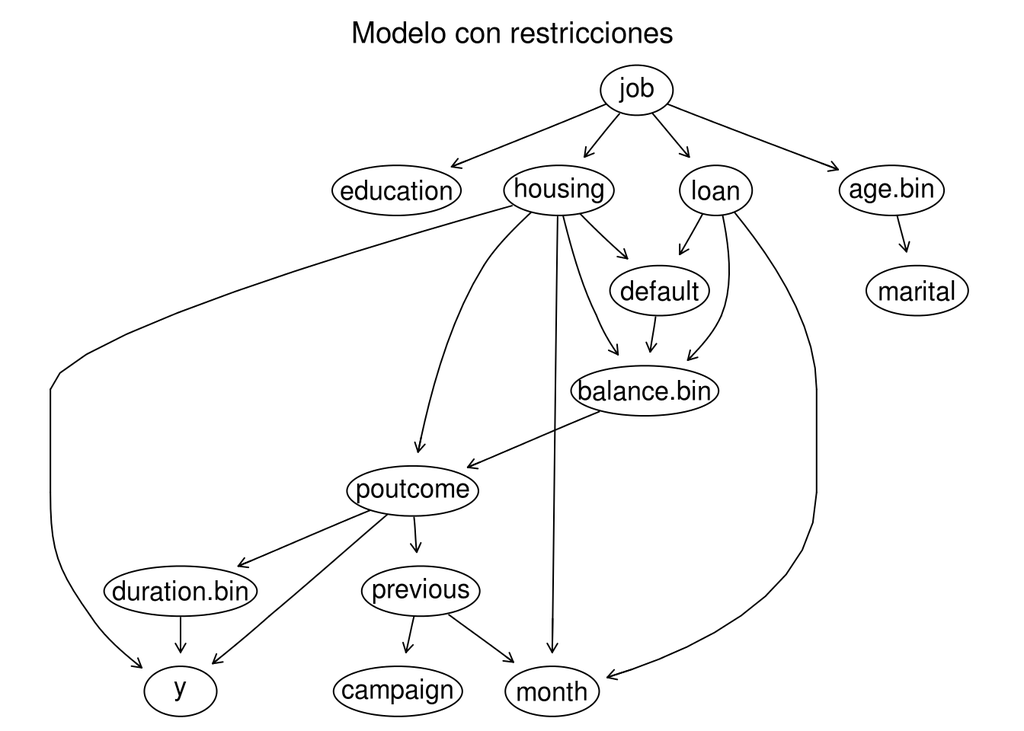

```r
graphviz.plot(fit,shape="ellipse",main="Modelo con restricciones")
```

## 2

Aprender estructura (3). Con el objetico de crear una red más robusta. Genera muestras bootstrap (a partir de los datos de entrenamiento), y calcula una red promedio. Recuerda incluir tu conocimiento experto (whitelists/blacklists).

*Describe cuantas muestras usaste y el umbral que usaste para incluir un arco en la red promedio.* ¿Cuáles on los arcos con mayor fuerza? *Refleja la fuerza de los arcos en una gráfica de tu red (usando como medida de fuerza la correspondiente a la función boot.strength).

### Bootstrap

Realizaremos 500 muestras bootstrap del mismo tamaño que el conjunto de entrenamiento. Mantendremos como criterio el bic y el conocimiento de experto que se introdujo en la generación de la lista negra del problema 1.

```r
bs <- boot.strength(mkt_train, R=500, m=30000, algorithm='hc', algorithm.args=list(score='bic', blacklist=b.list))
kable(head(bs %>% arrange(-strength), n=20))
```

| from | to | strength | direction |
| --- | --- | --- | --- |
| job | education | 1 | 0.859 |
| job | housing | 1 | 0.393 |
| job | age.bin | 1 | 0.607 |
| marital | age.bin | 1 | 0.332 |
| education | job | 1 | 0.141 |
| default | balance.bin | 1 | 0.473 |
| housing | job | 1 | 0.607 |
| housing | month | 1 | 0.999 |
| housing | poutcome | 1 | 0.977 |
| housing | balance.bin | 1 | 0.867 |
| loan | month | 1 | 0.995 |
| loan | balance.bin | 1 | 0.687 |
| month | housing | 1 | 0.001 |
| month | loan | 1 | 0.005 |
| campaign | previous | 1 | 0.274 |
| previous | campaign | 1 | 0.726 |
| previous | poutcome | 1 | 0.527 |
| poutcome | housing | 1 | 0.023 |
| poutcome | previous | 1 | 0.473 |
| y | duration.bin | 1 | 0.005 |

[figure not shown]

```r
strength.plot(fit, bs)
```

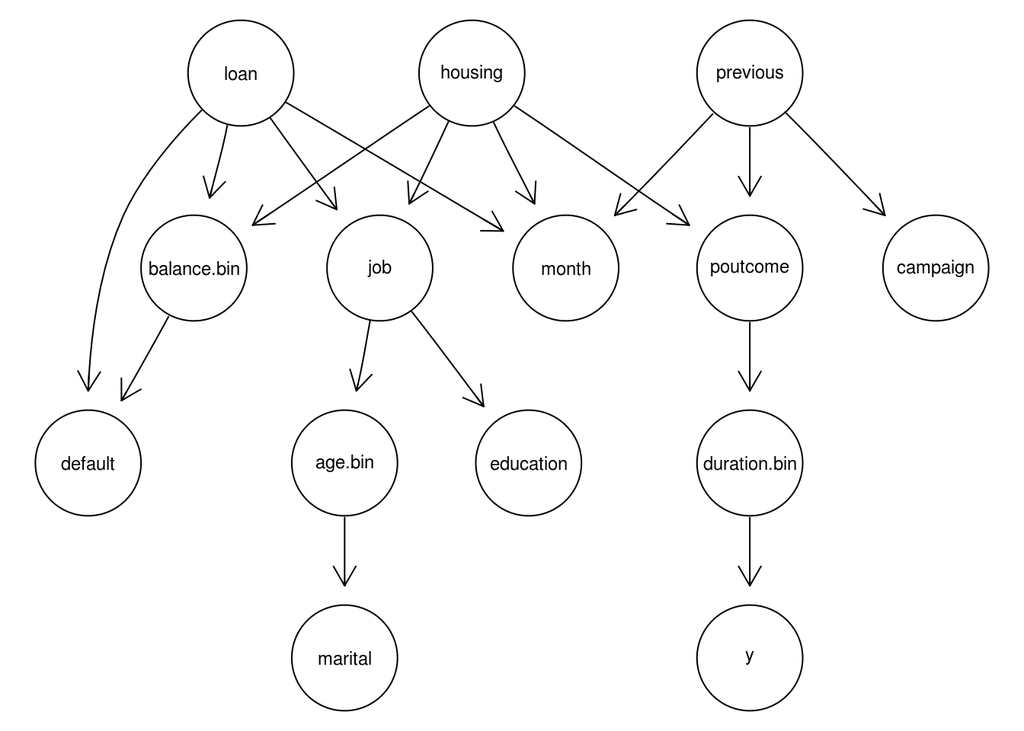

```r
anet <- averaged.network(bs, threshold=0.9)
#anet
graphviz.plot(anet)
```

## 3

Modelos locales (2). Una vez que elegiste la estructura final ajusta los modelos locales. Asegurate de que estén bien definidos para todas las variables, es decir, si la estimación de máxima verosimilitud no esta definida para alguna celda (NAs) utiliza un modelo logístico o multinomial o simplemente un suavizamiento de los conteos usando tamaño de muestra imaginaria.

*Justifica tu elección de modelo y parámetros, es decir, si usas tamaño de muestra imagiario que valor usas o si eliges un modelo logístico que interacciones incluyes.* Substituye las estimaciones en la red por las estimaciones de tus modelos locales. *Para el nodo correspondiente a y realiza gráficas de las probabilidades ajustadas con tu modelo y comparalas con las correspondientes a máxima verosimilitud.* Una vez que ajustaste un modelo para el nodo y (con la muestra de entrenamiento) úsalo para predecir el valor de y en la muestra de prueba. *Repite las predicciones usando las estimaciones de máxima verosimilitud (nuevamente ajustas el modelo con los datos de entrenamiento y predices sobre los datos de prueba).* Puedes usar el predict de la función que estás usando en el modelo local (glm, bayesglm, etc.) o predict.grain (ver sección 15 de tutorial, una ventaja de usar predict.grain es que puede haber datos faltantes en los predictores y ocupa la evidencia existente y la estructura de la red para predecir las variables de interés). *Del conjunto de personas con resultado positivo (y = yes) ¿Qué porcentaje clasificas correcto usando cada uno de los dos modelos locales?

### Modelos locales

```r
fit_mle <- bn.fit(anet, data = mkt_train, method = 'mle')
fit_mle
```

```
##
##   Bayesian network parameters
##
##   Parameters of node job (multinomial distribution)
##
## Conditional probability table:
##
## , , loan = no
##
##                housing
## job                    no       yes
##   admin.        0.0950127 0.1240849
##   blue-collar   0.1223595 0.2886859
##   entrepreneur  0.0265580 0.0314561
##   housemaid     0.0432991 0.0160180
##   management    0.2469103 0.1891716
##   retired       0.0904549 0.0195695
##   self-employed 0.0407573 0.0303689
##   services      0.0645105 0.1043705
##   student       0.0390043 0.0121041
##   technician    0.1731966 0.1602522
##   unemployed    0.0428609 0.0226861
##   unknown       0.0150758 0.0012322
##
## , , loan = yes
##
##                housing
## job                    no       yes
##   admin.        0.1426332 0.1333333
##   blue-collar   0.1995820 0.2607639
##   entrepreneur  0.0517241 0.0468750
##   housemaid     0.0308255 0.0149306
##   management    0.1891327 0.1607639
##   retired       0.0673981 0.0215278
##   self-employed 0.0287356 0.0288194
##   services      0.0987461 0.1284722
##   student       0.0026123 0.0003472
##   technician    0.1724138 0.1857639
##   unemployed    0.0156740 0.0177083
##   unknown       0.0005225 0.0006944
```

[output cut: 294 more lines]

```
## balance.bin      no     yes
##   ahorrador 0.84326 0.82569
##   deudor    0.15674 0.17431
##
##
##   Parameters of node duration.bin (multinomial distribution)
##
## Conditional probability table:
##
##              poutcome
## duration.bin  failure   other success unknown
##   de0a103     0.24099 0.25637 0.09073 0.25378
##   de103a180   0.27306 0.23172 0.19556 0.25170
##   de180a319   0.25596 0.23254 0.36794 0.24338
##   de319a4918] 0.22999 0.27938 0.34577 0.25113
```

```r
# condicionando a housing
probs_est_mle <- data.frame(fit_mle[['housing']]$prob)
names(probs_est_mle)[2] <- 'mle'
probs_est_mle
```

```
##   Var1    mle
## 1   no 0.4441
## 2  yes 0.5559
```

Esta definida para todas las celdas, sin embargo tenemos una matriz rala. Para solucionar vamos a suavizar y usar un modelo logístico para ver cuál funciona mejor

#### Suavizamiento

```r
fit_iss <- bn.fit(anet, data = mkt_train, method = 'bayes', iss =100)
fit_iss
```

```
##
##   Bayesian network parameters
##
##   Parameters of node job (multinomial distribution)
##
## Conditional probability table:
##
## , , loan = no
##
##                housing
## job                   no      yes
##   admin.        0.094987 0.124011
##   blue-collar   0.122274 0.288315
##   entrepreneur  0.026682 0.031550
##   housemaid     0.043387 0.016140
##   management    0.246553 0.188980
##   retired       0.090439 0.019685
##   self-employed 0.040850 0.030465
##   services      0.064552 0.104332
##   student       0.039101 0.012233
##   technician    0.173000 0.160113
##   unemployed    0.042949 0.022796
##   unknown       0.015225 0.001381
##
## , , loan = yes
##
##                housing
## job                   no      yes
##   admin.        0.141869 0.132903
##   blue-collar   0.198083 0.259237
##   entrepreneur  0.052132 0.047189
##   housemaid     0.031502 0.015519
##   management    0.187769 0.160098
##   retired       0.067604 0.022060
##   self-employed 0.029440 0.029289
##   services      0.098547 0.128084
##   student       0.003653 0.001061
##   technician    0.171265 0.184882
##   unemployed    0.016546 0.018273
##   unknown       0.001590 0.001406
```

[output cut: 294 more lines]

```
## balance.bin      no     yes
##   ahorrador 0.83883 0.82289
##   deudor    0.16117 0.17711
##
##
##   Parameters of node duration.bin (multinomial distribution)
##
## Conditional probability table:
##
##              poutcome
## duration.bin  failure   other success unknown
##   de0a103     0.24106 0.25624 0.09464 0.25378
##   de103a180   0.27289 0.23209 0.19690 0.25170
##   de180a319   0.25591 0.23289 0.36504 0.24339
##   de319a4918] 0.23015 0.27878 0.34341 0.25113
```

```r
probs_est_bayes <- data.frame(fit_iss[['housing']]$prob)
names(probs_est_bayes)[2] <- 'bayes'
probs_1 <- join(probs_est_mle, probs_est_bayes)
probs_1
```

```
##   Var1    mle  bayes
## 1   no 0.4441 0.4443
## 2  yes 0.5559 0.5557
```

```r
# si disminuimos iss a 50  "smaller"
fit_iss_s <- bn.fit(anet, data = mkt_train, method = 'bayes', iss =50)
probs_est_bayes_s <- data.frame(fit_iss_s[['housing']]$prob)
names(probs_est_bayes_s)[2] <- 'bayes_s'

# si aumentamos iss a 150  "bigger"
fit_iss_b <- bn.fit(anet, data = mkt_train, method = 'bayes', iss =150)
probs_est_bayes_b <- data.frame(fit_iss_b[['housing']]$prob)
names(probs_est_bayes_b)[2] <- 'bayes_b'

#las unimos
probs_2 <- join(join(probs_est_mle, probs_est_bayes), join(probs_est_bayes_s,
                                                           probs_est_bayes_b))
probs_2
```

```
##   Var1    mle  bayes bayes_s bayes_b
## 1   no 0.4441 0.4443  0.4442  0.4444
## 2  yes 0.5559 0.5557  0.5558  0.5556
```

```r
# podríamos hacer validacion cruzada  aunque dado que tenemos muchas observaciones creo mle funciona bien
```

En general comparando máxima verosimilitud y los diferentes tamaños de muestra imaginaria nos dan lo mismo

### Modelo Logístico

```r
dat_res <- mkt_train %>%
  group_by(housing, previous, poutcome, duration.bin, y)%>%
  summarise (num = n ()) %>%
  ungroup() %>%
  group_by(housing, previous, poutcome, duration.bin) %>%
  mutate (total = sum(num)) %>%
  ungroup () %>%
  mutate (prop= num /total)
dat_res

dat_res_sub <- filter(dat_res, y=='yes', num >5)

cuadrado <- function(x){x ^ 2}
ggplot(dat_res_sub, aes(x = housing, y = previous, colour = duration.bin,
  group = duration.bin)) +
  geom_point(aes(size = sqrt(num))) +
  geom_jitter() +
  facet_wrap(~poutcome) +
  scale_size_continuous("# obs.", labels = cuadrado) +
  theme(axis.text.x = element_text(angle = 45, hjust = 1))
```

[output not shown]

```r
# modelo nulo
mod_1 <- bayesglm(y ~ 1, data = mkt_train,
  prior.scale = 2.5, family = 'binomial')
display(mod_1)
```

```
## bayesglm(formula = y ~ 1, family = "binomial", data = mkt_train,
##     prior.scale = 2.5)
##             coef.est coef.se
## (Intercept) -2.02     0.02
## ---
## n = 30000, k = 1
## residual deviance = 21731.0, null deviance = 21731.0 (difference = 0.0)
```

```r
#modelo sencillo
mod_2 <- bayesglm(y ~ housing + previous+ poutcome + duration.bin,
                  data = mkt_train,
  prior.scale = 2.5, family = 'binomial')
display(mod_2)
```

```
## bayesglm(formula = y ~ housing + previous + poutcome + duration.bin,
##     family = "binomial", data = mkt_train, prior.scale = 2.5)
##                         coef.est coef.se
## (Intercept)             -5.20     0.87
## housingyes              -0.94     0.04
## previousyes              1.48     0.87
## poutcomeother            0.24     0.10
## poutcomesuccess          2.39     0.10
## poutcomeunknown          0.88     0.87
## duration.binde103a180    1.47     0.12
## duration.binde180a319    2.24     0.12
## duration.binde319a4918]  3.68     0.11
## ---
## n = 30000, k = 9
## residual deviance = 16179.1, null deviance = 21731.0 (difference = 5551.9)
```

```r
#modelo saturado
mod_3 <- bayesglm(y ~ housing * previous * poutcome *duration.bin,
                  data = mkt_train,
  prior.scale = 2.5, family = 'binomial')
display(mod_3)
```

```
## bayesglm(formula = y ~ housing * previous * poutcome * duration.bin,
##     family = "binomial", data = mkt_train, prior.scale = 2.5)
##                                                                coef.est
## (Intercept)                                                    -4.06
## housingyes                                                     -0.78
## previousyes                                                     0.61
## housingyes:previousyes                                         -0.25
## poutcomeother                                                   0.11
## poutcomesuccess                                                 1.22
## poutcomeunknown                                                -0.42
## housingyes:poutcomeother                                       -0.22
## housingyes:poutcomesuccess                                      0.06
## housingyes:poutcomeunknown                                     -0.10
## previousyes:poutcomeother                                       0.11
## previousyes:poutcomesuccess                                     1.22
## previousyes:poutcomeunknown                                     0.19
## housingyes:previousyes:poutcomeother                           -0.22
## housingyes:previousyes:poutcomesuccess                          0.06
## housingyes:previousyes:poutcomeunknown                          0.43
## duration.binde103a180                                           1.19
## duration.binde180a319                                           1.77
## duration.binde319a4918]                                         2.10
## housingyes:duration.binde103a180                               -0.35
## housingyes:duration.binde180a319                               -0.56
## housingyes:duration.binde319a4918]                             -0.06
## previousyes:duration.binde103a180                               0.46
## previousyes:duration.binde180a319                               0.79
## previousyes:duration.binde319a4918]                             1.11
## housingyes:previousyes:duration.binde103a180                   -0.13
## housingyes:previousyes:duration.binde180a319                   -0.22
## housingyes:previousyes:duration.binde319a4918]                  0.14
## poutcomeother:duration.binde103a180                            -0.06
## poutcomesuccess:duration.binde103a180                          -0.26
## poutcomeunknown:duration.binde103a180                           0.54
## poutcomeother:duration.binde180a319                             0.05
## poutcomesuccess:duration.binde180a319                          -0.16
## poutcomeunknown:duration.binde180a319                           0.73
## poutcomeother:duration.binde319a4918]                           0.01
## poutcomesuccess:duration.binde319a4918]                        -0.34
## poutcomeunknown:duration.binde319a4918]                         1.61
```

[output cut: 80 more lines]

```
## previousyes:poutcomeother:duration.binde319a4918]               1.80
## previousyes:poutcomesuccess:duration.binde319a4918]             1.79
## previousyes:poutcomeunknown:duration.binde319a4918]             2.29
## housingyes:previousyes:poutcomeother:duration.binde103a180      1.84
## housingyes:previousyes:poutcomesuccess:duration.binde103a180    1.81
## housingyes:previousyes:poutcomeunknown:duration.binde103a180    2.37
## housingyes:previousyes:poutcomeother:duration.binde180a319      1.83
## housingyes:previousyes:poutcomesuccess:duration.binde180a319    1.81
## housingyes:previousyes:poutcomeunknown:duration.binde180a319    2.50
## housingyes:previousyes:poutcomeother:duration.binde319a4918]    1.83
## housingyes:previousyes:poutcomesuccess:duration.binde319a4918]  1.81
## housingyes:previousyes:poutcomeunknown:duration.binde319a4918]  2.29
## ---
## n = 30000, k = 64
## residual deviance = 15956.9, null deviance = 21731.0 (difference = 5774.1)
```

```r
mod_1$aic
```

```
## [1] 21733
```

```r
mod_2$aic
```

```
## [1] 16197
```

```r
mod_3$aic
```

```
## [1] 16085
```

El modelo saturado es el que tiene menor AIC

#### Predecir

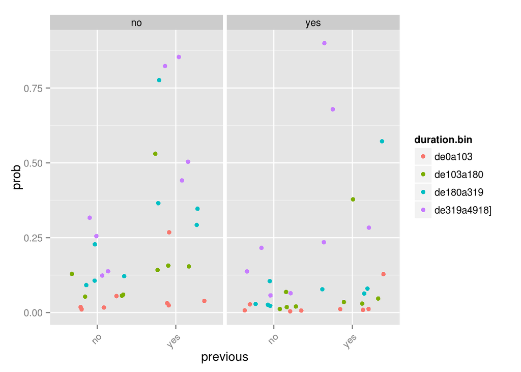

```r
grid_1 <- expand.grid(list(housing = unique(mkt_test$housing),
  previous = unique(mkt_test$previous),
  poutcome = unique(mkt_test$poutcome),
  duration.bin= unique(mkt_test$duration.bin)), stringsAsFactors=FALSE)

grid_1$prob <- predict(mod_3, grid_1, type='response')



grid_2 <- filter(grid_1, previous!='unknown')
ggplot(grid_2, aes(x = previous, y = prob, colour = duration.bin,
                   group = duration.bin))+
  geom_jitter() +
  facet_wrap(~ housing) +
  theme(axis.text.x=element_text(angle = 45, hjust = 1))
```

```r
#incluyendo intervalos de probabilidad

#library (gRain) No lo usamos por que no compila si con el predict.grain

sims_1 <- sim(mod_3, 100)
mod_3$coefficients <- sims_1@coef[3,]
grid_1$prob <- predict(mod_3, grid_1, type='response')
display(mod_3)
```

```
## bayesglm(formula = y ~ housing * previous * poutcome * duration.bin,
##     family = "binomial", data = mkt_train, prior.scale = 2.5)
##                                                                coef.est
## (Intercept)                                                    -2.84
## housingyes                                                      1.62
## previousyes                                                    -0.54
## housingyes:previousyes                                         -2.57
## poutcomeother                                                  -0.45
## poutcomesuccess                                                 0.05
## poutcomeunknown                                                -2.08
## housingyes:poutcomeother                                       -1.65
## housingyes:poutcomesuccess                                      0.07
## housingyes:poutcomeunknown                                     -2.37
## previousyes:poutcomeother                                      -0.67
## previousyes:poutcomesuccess                                     1.97
## previousyes:poutcomeunknown                                     0.29
## housingyes:previousyes:poutcomeother                            1.62
## housingyes:previousyes:poutcomesuccess                          0.74
## housingyes:previousyes:poutcomeunknown                         -0.46
## duration.binde103a180                                           1.86
## duration.binde180a319                                           0.16
## duration.binde319a4918]                                         3.24
## housingyes:duration.binde103a180                                0.01
## housingyes:duration.binde180a319                                0.08
## housingyes:duration.binde319a4918]                             -0.09
## previousyes:duration.binde103a180                              -0.20
## previousyes:duration.binde180a319                               2.38
## previousyes:duration.binde319a4918]                             0.02
## housingyes:previousyes:duration.binde103a180                   -0.67
## housingyes:previousyes:duration.binde180a319                   -0.93
## housingyes:previousyes:duration.binde319a4918]                 -0.02
## poutcomeother:duration.binde103a180                             4.13
## poutcomesuccess:duration.binde103a180                          -2.17
## poutcomeunknown:duration.binde103a180                           0.37
## poutcomeother:duration.binde180a319                             0.04
## poutcomesuccess:duration.binde180a319                           1.09
## poutcomeunknown:duration.binde180a319                           2.76
## poutcomeother:duration.binde319a4918]                          -0.55
## poutcomesuccess:duration.binde319a4918]                        -0.23
## poutcomeunknown:duration.binde319a4918]                         0.94
```

[output cut: 80 more lines]

```
## previousyes:poutcomeother:duration.binde319a4918]               1.80
## previousyes:poutcomesuccess:duration.binde319a4918]             1.79
## previousyes:poutcomeunknown:duration.binde319a4918]             2.29
## housingyes:previousyes:poutcomeother:duration.binde103a180      1.84
## housingyes:previousyes:poutcomesuccess:duration.binde103a180    1.81
## housingyes:previousyes:poutcomeunknown:duration.binde103a180    2.37
## housingyes:previousyes:poutcomeother:duration.binde180a319      1.83
## housingyes:previousyes:poutcomesuccess:duration.binde180a319    1.81
## housingyes:previousyes:poutcomeunknown:duration.binde180a319    2.50
## housingyes:previousyes:poutcomeother:duration.binde319a4918]    1.83
## housingyes:previousyes:poutcomesuccess:duration.binde319a4918]  1.81
## housingyes:previousyes:poutcomeunknown:duration.binde319a4918]  2.29
## ---
## n = 30000, k = 64
## residual deviance = 15956.9, null deviance = 21731.0 (difference = 5774.1)
```

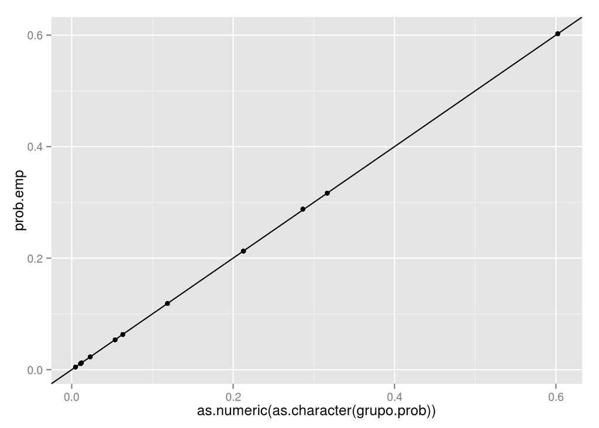

```r
dat_x <- ddply(data.frame(i=1:100), 'i', function(df){
  mod_3$coefficients <- sims_1@coef[df$i,]
  grid_1$prob <- predict(mod_3, grid_1, type='response')
  grid_1$sim.no <- df$i
  grid_1
})


mkt_train$prob.1 <- predict(mod_3, type='response')
mkt_train$grupo.prob <- cut2(mkt_train$prob.1, g=20, levels.mean=TRUE)

dat.cal <- ddply(mkt_train, c('grupo.prob'), summarise, total=length(housing),
  total.y=sum(y=='yes'))
dat.cal$prob.emp <- dat.cal$total.y/dat.cal$total
ggplot(dat.cal, aes(x=as.numeric(as.character(grupo.prob)), y=prob.emp)) + geom_point() +
  geom_abline(intercept=0,slope=1)
```

## 4

Queries de probabilidad condicional (1). Para estos incisos puedes usar gRain o samiam:

*$p(Y=1) =$* $p(Y=1|JOB=unemployed, MARITAL=single, EDUCATION=primary) =$ *$p(JOB=admin.|MARITAL=married, EDUCATION=primary, BALANCE=1000) =$

### Probabilidades condicionales

```r
# para exportar la red a samiam
options(digits=4)
write.net ("fit_mle.net", fit_mle)

comp_fit_mle <- compile(as.grain(fit_mle))
query_1 <- setEvidence(comp_fit_mle, nodes = c('y'),
  states = c('yes'))
querygrain(query_1)
```

```
## $job
## job
##        admin.   blue-collar  entrepreneur     housemaid    management
##      0.115291      0.217272      0.032424      0.027245      0.208384
##       retired self-employed      services       student    technician
##      0.049833      0.034024      0.091099      0.020508      0.168244
##    unemployed       unknown
##      0.029335      0.006342
##
## $housing
## housing
##     no    yes
## 0.4478 0.5522
##
## $loan
## loan
##     no    yes
## 0.8402 0.1598
##
## $balance.bin
## balance.bin
## ahorrador    deudor
##   0.91649   0.08351
##
## $default
## default
##      no     yes
## 0.98169 0.01831
##
## $month
## month
##      apr      aug      dec      feb      jan      jul      jun      mar
## 0.063645 0.134401 0.005136 0.060475 0.031678 0.150415 0.116302 0.010737
##      may      nov      oct      sep
## 0.307453 0.088661 0.017516 0.013582
##
## $previous
## previous
##    no   yes
## 0.809 0.191
```

[output cut: 31 more lines]

```
## 0.00029705 0.00019803 0.00006601 0.00009902 0.00013202 0.00009902
##         37         38         39         41         43         44
## 0.00006601 0.00003301 0.00000000 0.00003301 0.00009902 0.00003301
##         46         50         51         55         58
## 0.00003301 0.00000000 0.00000000 0.00003301 0.00003301
##
## $education
## education
##   primary secondary  tertiary   unknown
##   0.15334   0.51449   0.29163   0.04054
##
## $duration.bin
## duration.bin
##     de0a103   de103a180   de180a319 de319a4918]
##     0.02402     0.11030     0.23160     0.63408
```

```r
query_2 <- setEvidence(comp_fit_mle,
                       nslist=list(y="yes", job="unemployed", marital="single", education="primary"))
querygrain(query_2)
```

```
## $housing
## housing
##     no    yes
## 0.5879 0.4121
##
## $loan
## loan
##     no    yes
## 0.9085 0.0915
##
## $balance.bin
## balance.bin
## ahorrador    deudor
##   0.93191   0.06809
##
## $default
## default
##     no    yes
## 0.9845 0.0155
##
## $month
## month
##     apr     aug     dec     feb     jan     jul     jun     mar     may
## 0.06074 0.17042 0.00687 0.06547 0.03524 0.13874 0.12726 0.01392 0.25463
##     nov     oct     sep
## 0.08710 0.02221 0.01741
##
## $previous
## previous
##     no    yes
## 0.8073 0.1927
##
## $poutcome
## poutcome
## failure   other success unknown
## 0.09658 0.04081 0.05508 0.80754
##
## $age.bin
## age.bin
##   de17a24   de24a31   de31a38   de38a45   de45a52   de52a59   de59a66
```

[output cut: 12 more lines]

```
##         19         20         21         22         23         24
## 0.00115277 0.00102103 0.00079047 0.00036230 0.00052698 0.00049405
##         25         26         27         28         29         30
## 0.00036230 0.00026349 0.00019762 0.00042817 0.00029643 0.00019762
##         31         32         33         34         35         36
## 0.00029643 0.00019762 0.00006587 0.00009881 0.00013175 0.00009881
##         37         38         39         41         43         44
## 0.00006587 0.00003294 0.00000000 0.00003294 0.00009881 0.00003294
##         46         50         51         55         58
## 0.00003294 0.00000000 0.00000000 0.00003294 0.00003294
##
## $duration.bin
## duration.bin
##     de0a103   de103a180   de180a319 de319a4918]
##     0.02387     0.10988     0.23179     0.63446
```

```r
query_3 <- setEvidence(comp_fit_mle,
                       nslist=list(job="admin.", marital="married", education="primary", balance.bin="ahorrador"))
querygrain(query_3)
```

```
## $housing
## housing
##     no    yes
## 0.4074 0.5926
##
## $loan
## loan
##     no    yes
## 0.8256 0.1744
##
## $default
## default
##       no      yes
## 0.990351 0.009649
##
## $month
## month
##      apr      aug      dec      feb      jan      jul      jun      mar
## 0.064149 0.125009 0.004490 0.058491 0.030326 0.154734 0.113874 0.009659
##      may      nov      oct      sep
## 0.322912 0.088444 0.015768 0.012143
##
## $previous
## previous
##     no    yes
## 0.8171 0.1829
##
## $poutcome
## poutcome
## failure   other success unknown
## 0.10790 0.04036 0.03450 0.81724
##
## $age.bin
## age.bin
##   de17a24   de24a31   de31a38   de38a45   de45a52   de52a59   de59a66
## 0.0012129 0.0899290 0.2977928 0.2294095 0.2138094 0.1312701 0.0346937
##   de66a73   de73a80   de80a87   de87a94  de94a95]
## 0.0015094 0.0003731 0.0000000 0.0000000 0.0000000
##
## $campaign
```

[output cut: 12 more lines]

```
## 0.00030000 0.00020000 0.00006667 0.00010000 0.00013333 0.00010000
##         37         38         39         41         43         44
## 0.00006667 0.00003333 0.00000000 0.00003333 0.00010000 0.00003333
##         46         50         51         55         58
## 0.00003333 0.00000000 0.00000000 0.00003333 0.00003333
##
## $duration.bin
## duration.bin
##     de0a103   de103a180   de180a319 de319a4918]
##      0.2469      0.2513      0.2486      0.2533
##
## $y
## y
##     no    yes
## 0.8823 0.1177
```

## 5

MAP-Maximum a Posteriori (1). Supón que observas evidencia E=e: $e={AGE=20,MARITAL=married,EDUCATION=secondary,DEFAULT=no,BALANCE=1000,MONTH=may,$ $CAMPAIGN=1}$

Sea $Y=V\ E$, esto es, Y son todas las variables que no están en la evidencia E.

*Para cada variables Yi en Y, ¿cuál es el valor más probable? Es decir, $argmaxyip(Yi=yi|E=e)$* Calcula los valores y de máxima probabilidad posterior $MAP(Y|E=e)$.

Dada la evidencia los resultados son los siguientes:

[figure not shown]

No he dado ni recibido ayuda no autorizada en la realización de este exámen.

Firmas

Andrea Fernández Conde

Andrea García Tapia